# Project Stage II - Statistical Analysis

**Making necessary imports**

```python
import pandas as pd
import seaborn as sns
import matplotlib.pyplot as plt
from sklearn.preprocessing import OneHotEncoder
```

#### **Reloading the newdata.csv we obtained from stage 1**

```python
import pandas as pd

df= pd.read_csv('newdata.csv')
df.head(5)
```

|  | video_id | first_trending_ts | views_day1 | likes_day1 | dislikes_day1 | comments_day1 | likes_ratio | comments_ratio | category_name | days_trending(target) |
| --- | --- | --- | --- | --- | --- | --- | --- | --- | --- | --- |
| 0 | -0CMnp02rNY | 2018-06-06 | 475965 | 6531 | 172 | 271 | 0.974340 | 0.000569 | Entertainment | 6 |
| 1 | -0NYY8cqdiQ | 2018-02-01 | 563746 | 4429 | 54 | 94 | 0.987954 | 0.000167 | Entertainment | 1 |
| 2 | -1Hm41N0dUs | 2018-04-29 | 1566807 | 32752 | 393 | 1490 | 0.988143 | 0.000951 | Comedy | 3 |
| 3 | -1yT-K3c6YI | 2017-11-29 | 129360 | 5214 | 108 | 516 | 0.979707 | 0.003989 | People & Blogs | 4 |
| 4 | -2RVw2_QyxQ | 2017-11-14 | 67429 | 438 | 23 | 23 | 0.950108 | 0.000341 | Education | 3 |

### Task 1- Descriptive Statistics (20 points)--Done by Riya

#### **a. Calcuate the selected features mean, median, variance, skewness and kurtosis. (10 points)**

**Features I will be performing mean, median, variance, skewness and kurtosis include views_day1,likes_day1, dislikes_day1, comments_day1, likes_ratio, comment_ratio.**

```python
def task_1 (df):
    columns_1=['views_day1','likes_day1', 'dislikes_day1', 'comments_day1', 'likes_ratio', 'comments_ratio']
    mean=df[columns_1].mean()
    median=df[columns_1].median()
    variance=df[columns_1].var()
    skw=df[columns_1].skew()
    krt=df[columns_1].kurtosis()

    final_result= pd.DataFrame ({'mean': mean, 'median': median,'variance': variance, 'skew': skw,'kurtosis': krt})
    return final_result
```

```python
task_1(df)
```

|  | mean | median | variance | skew | kurtosis |
| --- | --- | --- | --- | --- | --- |
| views_day1 | 656597.085472 | 270593.000000 | 1.494624e+12 | 6.640327 | 78.418707 |
| likes_day1 | 27023.285302 | 8141.000000 | 3.568966e+09 | 5.753812 | 46.381227 |
| dislikes_day1 | 855.434664 | 232.000000 | 5.508563e+06 | 9.679847 | 153.082632 |
| comments_day1 | 2852.647409 | 903.000000 | 3.347093e+07 | 4.688434 | 29.422010 |
| likes_ratio | 0.946717 | 0.971639 | 4.413004e-03 | -2.575378 | 7.346359 |
| comments_ratio | 0.004953 | 0.003678 | 1.977343e-05 | 1.822100 | 3.943963 |

#### **b. Identify the type of data: categorical or numerical. If numerical, is it continuous or discrete? Summarize your findings. (10 points)**

views_day1: This is a numerical and discrete variable likes_day1:This is a numerical and discrete variable dislikes_day1:This is a numerical and discrete variable comments_day1:This is a numerical and discrete variable

- These features are discrete variables because, they are countable whole numbers, they do not indicate precise values like decimals or fractions.

likes_ratio:This is a numerical and continous variable comment_ratio:This is a numerical and continous variable

- whereas a ratio can range from 0-1 indicating precise values in the form of decimals, hence they are continous.

Category_name is a categorical variable.

#### One hot encoding for categorical variable--category_names

Categorical features can still be included, but they must be encoded into numeric form (e.g., gender → 0/1)

```python
df_encoded = pd.get_dummies(df, columns=['category_name'],dtype=int)
```

```python
df_encoded.head(15)
```

|  | video_id | first_trending_ts | views_day1 | likes_day1 | dislikes_day1 | comments_day1 | likes_ratio | comments_ratio | days_trending(target) | category_name_Autos & Vehicles | ... | category_name_Howto & Style | category_name_Music | category_name_News & Politics | category_name_Nonprofits & Activism | category_name_People & Blogs | category_name_Pets & Animals | category_name_Science & Technology | category_name_Shows | category_name_Sports | category_name_Travel & Events |
| --- | --- | --- | --- | --- | --- | --- | --- | --- | --- | --- | --- | --- | --- | --- | --- | --- | --- | --- | --- | --- | --- |
| 0 | -0CMnp02rNY | 2018-06-06 | 475965 | 6531 | 172 | 271 | 0.974340 | 0.000569 | 6 | 0 | ... | 0 | 0 | 0 | 0 | 0 | 0 | 0 | 0 | 0 | 0 |
| 1 | -0NYY8cqdiQ | 2018-02-01 | 563746 | 4429 | 54 | 94 | 0.987954 | 0.000167 | 1 | 0 | ... | 0 | 0 | 0 | 0 | 0 | 0 | 0 | 0 | 0 | 0 |
| 2 | -1Hm41N0dUs | 2018-04-29 | 1566807 | 32752 | 393 | 1490 | 0.988143 | 0.000951 | 3 | 0 | ... | 0 | 0 | 0 | 0 | 0 | 0 | 0 | 0 | 0 | 0 |
| 3 | -1yT-K3c6YI | 2017-11-29 | 129360 | 5214 | 108 | 516 | 0.979707 | 0.003989 | 4 | 0 | ... | 0 | 0 | 0 | 0 | 1 | 0 | 0 | 0 | 0 | 0 |
| 4 | -2RVw2_QyxQ | 2017-11-14 | 67429 | 438 | 23 | 23 | 0.950108 | 0.000341 | 3 | 0 | ... | 0 | 0 | 0 | 0 | 0 | 0 | 0 | 0 | 0 | 0 |
| 5 | -2aVkGcI7ZA | 2018-04-27 | 1012527 | 19339 | 633 | 520 | 0.968306 | 0.000514 | 4 | 0 | ... | 0 | 1 | 0 | 0 | 0 | 0 | 0 | 0 | 0 | 0 |
| 6 | -2b4qSoMnKE | 2017-12-20 | 84744 | 1444 | 199 | 1610 | 0.878880 | 0.018998 | 2 | 0 | ... | 0 | 0 | 1 | 0 | 0 | 0 | 0 | 0 | 0 | 0 |
| 7 | -2wRFv-mScQ | 2018-02-14 | 703371 | 10350 | 260 | 567 | 0.975495 | 0.000806 | 4 | 0 | ... | 0 | 0 | 0 | 0 | 0 | 0 | 0 | 0 | 1 | 0 |
| 8 | -35jibKqbEo | 2018-02-15 | 545655 | 73480 | 727 | 6157 | 0.990203 | 0.011284 | 8 | 0 | ... | 0 | 1 | 0 | 0 | 0 | 0 | 0 | 0 | 0 | 0 |
| 9 | -39ysKKpE7I | 2018-04-24 | 385104 | 4028 | 343 | 1507 | 0.921528 | 0.003913 | 1 | 0 | ... | 0 | 0 | 0 | 0 | 0 | 0 | 0 | 0 | 1 | 0 |
| 10 | -3h4Xt9No9o | 2018-04-24 | 230360 | 6468 | 177 | 688 | 0.973363 | 0.002987 | 10 | 0 | ... | 0 | 0 | 1 | 0 | 0 | 0 | 0 | 0 | 0 | 0 |
| 11 | -3nEHRN6IPg | 2018-02-20 | 249601 | 10384 | 370 | 1023 | 0.965594 | 0.004099 | 5 | 0 | ... | 1 | 0 | 0 | 0 | 0 | 0 | 0 | 0 | 0 | 0 |
| 12 | -4s2MeUgduo | 2018-03-22 | 296237 | 38776 | 466 | 1342 | 0.988125 | 0.004530 | 13 | 0 | ... | 0 | 0 | 0 | 0 | 0 | 0 | 1 | 0 | 0 | 0 |
| 13 | -5aaJJQFvOg | 2018-02-23 | 390631 | 71090 | 635 | 4555 | 0.991147 | 0.011661 | 11 | 0 | ... | 0 | 1 | 0 | 0 | 0 | 0 | 0 | 0 | 0 | 0 |
| 14 | -66xHRJSPxs | 2018-05-09 | 744363 | 21224 | 534 | 3009 | 0.975457 | 0.004042 | 4 | 0 | ... | 0 | 0 | 0 | 0 | 0 | 0 | 0 | 0 | 0 | 0 |

15 rows × 25 columns

```python
df_encoded.columns
```

```
Index(['video_id', 'first_trending_ts', 'views_day1', 'likes_day1',
       'dislikes_day1', 'comments_day1', 'likes_ratio', 'comments_ratio',
       'days_trending(target)', 'category_name_Autos & Vehicles',
       'category_name_Comedy', 'category_name_Education',
       'category_name_Entertainment', 'category_name_Film & Animation',
       'category_name_Gaming', 'category_name_Howto & Style',
       'category_name_Music', 'category_name_News & Politics',
       'category_name_Nonprofits & Activism', 'category_name_People & Blogs',
       'category_name_Pets & Animals', 'category_name_Science & Technology',
       'category_name_Shows', 'category_name_Sports',
       'category_name_Travel & Events'],
      dtype='object')
```

```python
df_new=df_encoded[['video_id', 'first_trending_ts', 'views_day1', 'likes_day1',
       'dislikes_day1', 'comments_day1', 'likes_ratio', 'comments_ratio',
        'category_name_Autos & Vehicles',
       'category_name_Comedy', 'category_name_Education',
       'category_name_Entertainment', 'category_name_Film & Animation',
       'category_name_Gaming', 'category_name_Howto & Style',
       'category_name_Music', 'category_name_News & Politics',
       'category_name_Nonprofits & Activism', 'category_name_People & Blogs',
       'category_name_Pets & Animals', 'category_name_Science & Technology',
       'category_name_Shows', 'category_name_Sports',
       'category_name_Travel & Events', 'days_trending(target)']]
```

**The final dataframe with one hot encoded category names.**

```python
df_new.head(5)
```

|  | video_id | first_trending_ts | views_day1 | likes_day1 | dislikes_day1 | comments_day1 | likes_ratio | comments_ratio | category_name_Autos & Vehicles | category_name_Comedy | ... | category_name_Music | category_name_News & Politics | category_name_Nonprofits & Activism | category_name_People & Blogs | category_name_Pets & Animals | category_name_Science & Technology | category_name_Shows | category_name_Sports | category_name_Travel & Events | days_trending(target) |
| --- | --- | --- | --- | --- | --- | --- | --- | --- | --- | --- | --- | --- | --- | --- | --- | --- | --- | --- | --- | --- | --- |
| 0 | -0CMnp02rNY | 2018-06-06 | 475965 | 6531 | 172 | 271 | 0.974340 | 0.000569 | 0 | 0 | ... | 0 | 0 | 0 | 0 | 0 | 0 | 0 | 0 | 0 | 6 |
| 1 | -0NYY8cqdiQ | 2018-02-01 | 563746 | 4429 | 54 | 94 | 0.987954 | 0.000167 | 0 | 0 | ... | 0 | 0 | 0 | 0 | 0 | 0 | 0 | 0 | 0 | 1 |
| 2 | -1Hm41N0dUs | 2018-04-29 | 1566807 | 32752 | 393 | 1490 | 0.988143 | 0.000951 | 0 | 1 | ... | 0 | 0 | 0 | 0 | 0 | 0 | 0 | 0 | 0 | 3 |
| 3 | -1yT-K3c6YI | 2017-11-29 | 129360 | 5214 | 108 | 516 | 0.979707 | 0.003989 | 0 | 0 | ... | 0 | 0 | 0 | 1 | 0 | 0 | 0 | 0 | 0 | 4 |
| 4 | -2RVw2_QyxQ | 2017-11-14 | 67429 | 438 | 23 | 23 | 0.950108 | 0.000341 | 0 | 0 | ... | 0 | 0 | 0 | 0 | 0 | 0 | 0 | 0 | 0 | 3 |

5 rows × 25 columns

### Task 2 - Distribution Fitting (20 points) --- Xiuwen

#### **a. Select one suitable numerical feature from task 1. Propose a theoretical distribution (Normal, Binomial, Poisson, Exponential, Geometric, etc.) and explain why you choose it. (6 points)**

Selected Feature: Views Day 1

Proposed Distribution: Gamma Distribution

Reasoning:

1. Views data is strictly positive (Gamma supports positive values only)
2. The data is right-skewed with a heavy tail (Gamma can model this)
3. Real-world view counts often follow power-law or Gamma-like distributions
4. Gamma distribution is flexible with shape and scale parameters

```python
# Select 'views_day1' for distribution fitting
views_data = df['views_day1']
```

#### **b. Plot histogram of your feature, overlay a smooth curve of the fitted theoretical distribution (10 points). Discuss how your data fits the distribution. (4 points)**

[figure not shown]

```
Goodness of Fit Assessment:
Kolmogorov-Smirnov Test: statistic = 0.9998, p-value = 0.0000

Data Mean: 656597.09, Fitted Gamma Mean: 24421449.65
Data Variance: 1494623823312.74, Fitted Gamma Variance: 11.60
```

```python
import numpy as np
import matplotlib.pyplot as plt
import seaborn as sns
from scipy import stats
from scipy.stats import norm, poisson, expon, gamma
import warnings
warnings.filterwarnings('ignore')

# Fit Gamma distribution to the data
params = gamma.fit(views_data)
x = np.linspace(views_data.min(), views_data.max(), 1000)
pdf_fitted = gamma.pdf(x, *params)

# Plot
plt.figure(figsize=(12, 6))

# Histogram
plt.hist(views_data, bins=50, density=True, alpha=0.7, color='skyblue', label='Data Histogram')

# Fitted distribution
plt.plot(x, pdf_fitted, 'r-', linewidth=2, label=f'Fitted Gamma Distribution')

plt.xlabel('Views Day 1', fontsize=12)
plt.ylabel('Density', fontsize=12)
plt.title('Task 2b - Distribution Fitting for Views Day 1\nGamma Distribution Fit', fontsize=14)
plt.legend()
plt.grid(True, alpha=0.3)
plt.show()

# Goodness of fit assessment
print("\nGoodness of Fit Assessment:")
ks_stat, ks_pvalue = stats.kstest(views_data, 'gamma', args=params)
print(f"Kolmogorov-Smirnov Test: statistic = {ks_stat:.4f}, p-value = {ks_pvalue:.4f}")

# Calculate mean and variance of fitted distribution
shape, loc, scale = params
fitted_mean = shape * scale + loc
fitted_var = shape * scale**2

print(f"\nData Mean: {views_data.mean():.2f}, Fitted Gamma Mean: {fitted_mean:.2f}")
print(f"Data Variance: {views_data.var():.2f}, Fitted Gamma Variance: {fitted_var:.2f}")
```

### Task 3 - Point Estimate (20 points) --- Xiuwen

#### **a. Randomly select 100 samples from the feature selected in Task 2, caculate the sample mean and variance. Compare with the population mean and variance. (10 points)**

```python
# Set seed for reproducibility
np.random.seed(42)

# Random sample of 100
sample_100 = np.random.choice(views_data, size=100, replace=False)

# Calculate sample statistics
sample_mean = np.mean(sample_100)
sample_variance = np.var(sample_100, ddof=1)  # Sample variance

# Population statistics
population_mean = views_data.mean()
population_variance = views_data.var()

print("Task 3a - Sample vs Population Comparison:")
print("=" * 50)
print(f"Sample Size: 100")
print(f"Sample Mean: {sample_mean:,.2f}")
print(f"Population Mean: {population_mean:,.2f}")
print(f"Difference: {abs(sample_mean - population_mean):,.2f} ({abs((sample_mean - population_mean)/population_mean)*100:.2f}%)")
print(f"\nSample Variance: {sample_variance:,.2f}")
print(f"Population Variance: {population_variance:,.2f}")
print(f"Difference: {abs(sample_variance - population_variance):,.2f} ({abs((sample_variance - population_variance)/population_variance)*100:.2f}%)")
```

```
Task 3a - Sample vs Population Comparison:
==================================================
Sample Size: 100
Sample Mean: 780,382.59
Population Mean: 656,597.09
Difference: 123,785.50 (18.85%)

Sample Variance: 1,838,876,716,645.82
Population Variance: 1,494,623,823,312.74
Difference: 344,252,893,333.08 (23.03%)
```

#### **b. Repeat the random sampling 3 times and show how sample mean/variance vary due to randomness. Discuss your findings. (10 points)**

```python
print("\nTask 3b - Multiple Sampling Results:")
print("=" * 50)

sampling_results = []

for i in range(3):
    np.random.seed(i*10)  # Different seeds for different samples
    sample = np.random.choice(views_data, size=100, replace=False)

    sample_mean = np.mean(sample)
    sample_var = np.var(sample, ddof=1)

    sampling_results.append({
        'Sample': i+1,
        'Mean': sample_mean,
        'Variance': sample_var,
        'Mean_Diff_Pct': abs((sample_mean - population_mean) / population_mean * 100),
        'Var_Diff_Pct': abs((sample_var - population_variance) / population_variance * 100)
    })

    print(f"\nSample {i+1}:")
    print(f"  Mean: {sample_mean:,.2f} (Difference: {abs(sample_mean - population_mean):,.2f}, {abs((sample_mean - population_mean)/population_mean)*100:.2f}%)")
    print(f"  Variance: {sample_var:,.2f} (Difference: {abs(sample_var - population_variance):,.2f}, {abs((sample_var - population_variance)/population_variance)*100:.2f}%)")

# Create summary table
results_df = pd.DataFrame(sampling_results)
print("\n" + "="*50)
print("Summary of Sampling Variation:")
print(results_df.round(2))
```

```
Task 3b - Multiple Sampling Results:
==================================================

Sample 1:
  Mean: 886,401.23 (Difference: 229,804.14, 35.00%)
  Variance: 6,228,886,343,779.19 (Difference: 4,734,262,520,466.45, 316.75%)

Sample 2:
  Mean: 492,083.41 (Difference: 164,513.68, 25.06%)
  Variance: 468,117,582,281.96 (Difference: 1,026,506,241,030.78, 68.68%)

Sample 3:
  Mean: 675,687.27 (Difference: 19,090.18, 2.91%)
  Variance: 1,568,887,074,265.98 (Difference: 74,263,250,953.24, 4.97%)

==================================================
Summary of Sampling Variation:
   Sample       Mean      Variance  Mean_Diff_Pct  Var_Diff_Pct
0       1  886401.23  6.228886e+12          35.00        316.75
1       2  492083.41  4.681176e+11          25.06         68.68
2       3  675687.27  1.568887e+12           2.91          4.97
```

Sampling Implications: For highly skewed distributions like video views, larger sample sizes would be needed for stable variance estimates. The mean is relatively more stable across samples compared to variance. The Law of Large Numbers suggests that with larger samples, these estimates would converge to the population parameters.

### Task 4 - Correlation Analysis (20 points) ---- Naveena

#### **Among the features in task 1, calculate the correlation coefficients. Use a heatmap or correlation matrix for visualization.**

```
Correlation Matrix:
                views_day1  likes_day1  dislikes_day1  comments_day1  \
views_day1        1.000000    0.757170       0.630443       0.688181
likes_day1        0.757170    1.000000       0.542047       0.852406
dislikes_day1     0.630443    0.542047       1.000000       0.612102
comments_day1     0.688181    0.852406       0.612102       1.000000
likes_ratio       0.043093    0.165342      -0.167126       0.078768
comments_ratio   -0.073519    0.138658       0.060567       0.314516

                likes_ratio  comments_ratio
views_day1         0.043093       -0.073519
likes_day1         0.165342        0.138658
dislikes_day1     -0.167126        0.060567
comments_day1      0.078768        0.314516
likes_ratio        1.000000       -0.008333
comments_ratio    -0.008333        1.000000
```

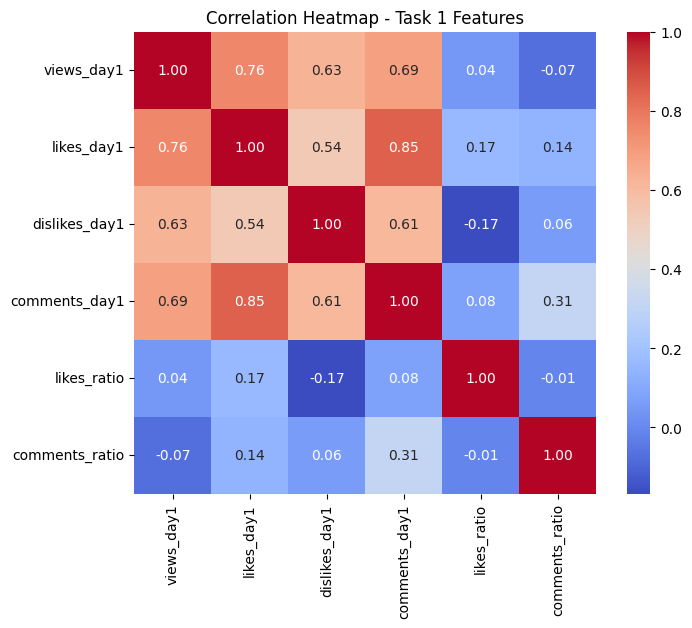

```python
features = ["views_day1", "likes_day1", "dislikes_day1",
            "comments_day1", "likes_ratio", "comments_ratio"]

df_task4 = df[features]

# Compute correlation matrix
corr_matrix = df_task4.corr()

# Print correlation matrix
print("Correlation Matrix:")
print(corr_matrix)

# Plot correlation heatmap
plt.figure(figsize=(8, 6))
sns.heatmap(corr_matrix, annot=True, cmap="coolwarm", fmt=".2f", cbar=True, square=True)
plt.title("Correlation Heatmap - Task 1 Features")
plt.show()
```

### Task 5 - Hypothesis Question Propose. (20 points)

Formulate 3 hypothsis questions based on your whole data. Choose 3 different variables to compare against.

For example: Does higher employment data lead to higher covid case? The variable here is employment data.

Make sure your hypothsis questions are meaningful, since we will test on it in next stage.

**hypothesis 1: does a higher number of views on the first day lead to a higher likes ratio?--riya**  
**hypothesis 2: Videos with a higher comments ratio are likely to trend for a longer duration.--naveena**  
**hypothesis 3: Different categories have significantly different average trending durations?--naveena**